```python
import geopandas as gpd
import numpy as np
import pandas as pd

import matplotlib.pyplot as plt

import gurobipy as gp
from gurobipy import GRB
```

# Lab 5: Exploring Bus Stop Placement in Santa Barbara

Introduction: In this lab, we delve into the intricate process of evaluating bus stop locations along Bus 11 in Santa Barbara.  
Public transportation plays a pivotal role in urban mobility, and strategically placing bus stops can significantly enhance accessibility and efficiency.  
Through the utilization of spatial optimization techniques, we aim to evaluate bus stops, considering factors such as proximity to residential areas and population density.

By leveraging geographic information systems (GIS) and mathematical modeling, we seek to find a balance between the number of bus stops and the average travel distance for residents.  
Through this exploration, we can gain valuable insights into enhancing public transportation systems while addressing urban mobility challenges.

## Step 1. Restore Bus 11 Line

#### Task: Retrieve Route of Bus 11.

**Steps:**

1. Download a California Transit lines (in shapefile) from [this link](https://data.ca.gov/dataset/ca-transit-routes).
2. Move the shapefile into the Data folder.
3. Load the shapefile, and assign the variable name to `calTrans`.
4. Find the linestring corresponding to Bus 11 in Santa Barbara.
5. A hint to start: Filter the route_id column value to be '11' and assign it to a new variable named `route_11`.

```python
calTrans = gpd.read_file("Data/CA_Transit_Routes/RR_CA_Transit_Routes.shp")
```

```python
eleven_calTrans = calTrans.loc[calTrans["route_id"] == "11"]

sb_eleven_calTrans = eleven_calTrans.loc[eleven_calTrans["agency"] == "Santa Barbara Metropolitan Transit District"]
```

```python
route_11 = eleven_calTrans.loc[eleven_calTrans["agency"] =="Santa Barbara Metropolitan Transit District"].reset_index()
```

```python
route_11
```

|  | index | OBJECTID | org_id | agency | route_id | route_type | route_name | shape_id | n_trips | base64_url | Shape_Leng | geometry |
| --- | --- | --- | --- | --- | --- | --- | --- | --- | --- | --- | --- | --- |
| 0 | 5499 | 5500 | recswCrw6a6htmXJ4 | Santa Barbara Metropolitan Transit District | 11 | 3 | UCSB | shp-11-01 | 10.0 | aHR0cHM6Ly9zYm10ZC5nb3YvZ29vZ2xlX3RyYW5zaXQvZm... | 27670.615169 | LINESTRING (-13343855.116 4086639.519, -133438... |
| 1 | 5500 | 5501 | recswCrw6a6htmXJ4 | Santa Barbara Metropolitan Transit District | 11 | 3 | UCSB | shp-11-02 | 23.0 | aHR0cHM6Ly9zYm10ZC5nb3YvZ29vZ2xlX3RyYW5zaXQvZm... | 27684.782249 | LINESTRING (-13343855.116 4086639.519, -133438... |
| 2 | 5501 | 5502 | recswCrw6a6htmXJ4 | Santa Barbara Metropolitan Transit District | 11 | 3 | UCSB | shp-11-53 | 11.0 | aHR0cHM6Ly9zYm10ZC5nb3YvZ29vZ2xlX3RyYW5zaXQvZm... | 26587.050207 | LINESTRING (-13325343.798 4085466.221, -133253... |
| 3 | 5502 | 5503 | recswCrw6a6htmXJ4 | Santa Barbara Metropolitan Transit District | 11 | 3 | UCSB | shp-11-54 | 19.0 | aHR0cHM6Ly9zYm10ZC5nb3YvZ29vZ2xlX3RyYW5zaXQvZm... | 26593.847570 | LINESTRING (-13325343.798 4085466.221, -133253... |
| 4 | 5503 | 5504 | recswCrw6a6htmXJ4 | Santa Barbara Metropolitan Transit District | 11 | 3 | UCSB | shp-11-55 | 1.0 | aHR0cHM6Ly9zYm10ZC5nb3YvZ29vZ2xlX3RyYW5zaXQvZm... | 26868.826155 | LINESTRING (-13325343.798 4085466.221, -133253... |
| 5 | 5504 | 5505 | recswCrw6a6htmXJ4 | Santa Barbara Metropolitan Transit District | 11 | 3 | UCSB | shp-11-56 | 3.0 | aHR0cHM6Ly9zYm10ZC5nb3YvZ29vZ2xlX3RyYW5zaXQvZm... | 26593.847570 | LINESTRING (-13325343.798 4085466.221, -133253... |

```python
del calTrans
```

#### Task: Retrieve Bus stops nearby Bus 11 route

**Steps:**

1. Download the Southern California OSM dataset. (search in google!)
2. Move the *gis_osm_transport_free_1.shp* file to the Data folder.
3. Load the shapefile into a variable named `stops`.
4. Filter the `stops` variable to include only those with the fclass column value "bus_stop".
5. Update the `stops` variable to include only the stops within a 30-meter radius from the `route_11` linestring.

**Hint:** Ensure that all datasets used in Lab 5 are in the same CRS as `route_11` (EPSG:3857). The linear unit is Meter.

```python
stops = gpd.read_file("Data/socal-latest-free/gis_osm_transport_free_1.shp")
```

```python
stops = stops.loc[stops["fclass"] == "bus_stop"].reset_index()
```

```python
route_11 = route_11.to_crs("epsg:3857")
stops = stops.to_crs("epsg:3857")
```

```python
stops = stops.loc[stops.within(route_11.unary_union.buffer(30))].reset_index()
```

#### Task: Replace the NA value in the "name" column of stops with an empty string, "".

**Steps to Follow:**

1. Use the `.loc` function to identify the rows with NA values in the "name" column. (Refer to Lab 1)
2. Utilize the `.loc` function to update the values in the DataFrame. Check out the example below for reference.

```
# Example of using .loc function to update values in a DataFrame
df.loc[df['column_name'] == 'old_value', 'column_name'] = 'new_value'
```

```python
stops["name"].isnull().sum()
```

```
1
```

```python
stops.loc[stops['name'].isna(), 'name'] = ""
```

#### Task: Visualize the stops and route_11 together using Matplotlib.

```python
route_11
```

|  | index | OBJECTID | org_id | agency | route_id | route_type | route_name | shape_id | n_trips | base64_url | Shape_Leng | geometry |
| --- | --- | --- | --- | --- | --- | --- | --- | --- | --- | --- | --- | --- |
| 0 | 5499 | 5500 | recswCrw6a6htmXJ4 | Santa Barbara Metropolitan Transit District | 11 | 3 | UCSB | shp-11-01 | 10.0 | aHR0cHM6Ly9zYm10ZC5nb3YvZ29vZ2xlX3RyYW5zaXQvZm... | 27670.615169 | LINESTRING (-13343855.116 4086639.519, -133438... |
| 1 | 5500 | 5501 | recswCrw6a6htmXJ4 | Santa Barbara Metropolitan Transit District | 11 | 3 | UCSB | shp-11-02 | 23.0 | aHR0cHM6Ly9zYm10ZC5nb3YvZ29vZ2xlX3RyYW5zaXQvZm... | 27684.782249 | LINESTRING (-13343855.116 4086639.519, -133438... |
| 2 | 5501 | 5502 | recswCrw6a6htmXJ4 | Santa Barbara Metropolitan Transit District | 11 | 3 | UCSB | shp-11-53 | 11.0 | aHR0cHM6Ly9zYm10ZC5nb3YvZ29vZ2xlX3RyYW5zaXQvZm... | 26587.050207 | LINESTRING (-13325343.798 4085466.221, -133253... |
| 3 | 5502 | 5503 | recswCrw6a6htmXJ4 | Santa Barbara Metropolitan Transit District | 11 | 3 | UCSB | shp-11-54 | 19.0 | aHR0cHM6Ly9zYm10ZC5nb3YvZ29vZ2xlX3RyYW5zaXQvZm... | 26593.847570 | LINESTRING (-13325343.798 4085466.221, -133253... |
| 4 | 5503 | 5504 | recswCrw6a6htmXJ4 | Santa Barbara Metropolitan Transit District | 11 | 3 | UCSB | shp-11-55 | 1.0 | aHR0cHM6Ly9zYm10ZC5nb3YvZ29vZ2xlX3RyYW5zaXQvZm... | 26868.826155 | LINESTRING (-13325343.798 4085466.221, -133253... |
| 5 | 5504 | 5505 | recswCrw6a6htmXJ4 | Santa Barbara Metropolitan Transit District | 11 | 3 | UCSB | shp-11-56 | 3.0 | aHR0cHM6Ly9zYm10ZC5nb3YvZ29vZ2xlX3RyYW5zaXQvZm... | 26593.847570 | LINESTRING (-13325343.798 4085466.221, -133253... |

#### Question 1: Plot `stops` and `route_11` using Folium. ( 1 pt )

**Grading Rubric:**

1. Both stops and route_11 are visible on the Folium map.
2. Popups are available for stop points, indicating the "name" column value. (1 pt)

**Hints:**

1. Copy and paste your matplotlib plotting code and ask ChatGPT to convert it into Folium with popups for stops.
2. Create new variables, `stops_` and `route_11_`, using the .to_crs() function. They must be in WGS 84 CRS for interactive mapping.

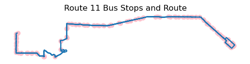

```python
A = route_11.plot()
stops.plot(ax=A, color="pink")
plt.axis("off")

plt.title("Route 11 Bus Stops and Route")
```

```python
route_11_ = route_11.to_crs("WGS84")
stops_ = stops.to_crs("WGS84")
```

```python
import folium

route_midpoint = route_11_.iloc[0].geometry.interpolate(0.5, normalized=True)
m = folium.Map(location=[route_midpoint.y, route_midpoint.x], zoom_start=13)

for idx, row in stops_.iterrows():
    folium.Marker(
        location=[row.geometry.y, row.geometry.x],
        popup=row['name'],
        icon=folium.Icon(color='pink')
    ).add_to(m)

folium.PolyLine(
    locations=[(coord[1], coord[0]) for coord in route_11_.iloc[0].geometry.coords],
    color='blue',
    weight=5,
    opacity=0.8
).add_to(m)

m.save('map.html')
m
```

Make this Notebook Trusted to load map: File -> Trust Notebook

[interactive chart not shown]

#### Task: Find the out bus stops on Bus 11 route.

Steps

1. Visit the [Moovit website for Bus 11](https://moovitapp.com/index/en/public_transit-line-11-Los_Angeles_CA-302-2414244-52418427-1).
2. Copy the list of bus stops.
3. Paste the copied list into a variable named `stops_11`.
   - It is okay to include the "VIEW FULL SCHEDULE" text after each stop name.
   - Since the strings span multiple lines, use triple quotation marks (`"""`) to create multiline strings.

```python
example = """

Hi this is an example for a multiline string

Hi this is an example for a multiline string

"""

example
```

```
'\n\nHi this is an example for a multiline string\n\nHi this is an example for a multiline string\n\n'
```

```python
stops_11 = """Transit Center
VIEW FULL SCHEDULE
Chapala & Anapamu
VIEW FULL SCHEDULE
Sola & Chapala
VIEW FULL SCHEDULE
State & Sola
VIEW FULL SCHEDULE
State & Arrellaga
VIEW FULL SCHEDULE
State & Valerio
VIEW FULL SCHEDULE
State & Islay
VIEW FULL SCHEDULE
State & Mission
VIEW FULL SCHEDULE
State & Pueblo
VIEW FULL SCHEDULE
State & Quinto
VIEW FULL SCHEDULE
State & Constance
VIEW FULL SCHEDULE
State & Alamar
VIEW FULL SCHEDULE
State & Calle Laureles
VIEW FULL SCHEDULE
State & Calle Palo Colorado
VIEW FULL SCHEDULE
State & San Roque
VIEW FULL SCHEDULE
State & Broadmoor
VIEW FULL SCHEDULE
State & Ontare
VIEW FULL SCHEDULE
State & Hitchcock
VIEW FULL SCHEDULE
State & Hope
VIEW FULL SCHEDULE
State & LA Cumbre
VIEW FULL SCHEDULE
State & Highway 154
VIEW FULL SCHEDULE
Hollister & Nogal
VIEW FULL SCHEDULE
Hollister & Auhay East
VIEW FULL SCHEDULE
Hollister & Sport Center
VIEW FULL SCHEDULE
Hollister & San Antonio
VIEW FULL SCHEDULE
Hollister & Puente
VIEW FULL SCHEDULE
Hollister & Turnpike
VIEW FULL SCHEDULE
Hollister & San Marcos
VIEW FULL SCHEDULE
Hollister & Walnut
VIEW FULL SCHEDULE
Hollister & Lassen
VIEW FULL SCHEDULE
Hollister & Patterson
VIEW FULL SCHEDULE
Hollister & Sumida
VIEW FULL SCHEDULE
Hollister & Ward
VIEW FULL SCHEDULE
Hollister and Kellogg WB
VIEW FULL SCHEDULE
Hollister & Wendy's
VIEW FULL SCHEDULE
Hollister & Nectarine
VIEW FULL SCHEDULE
Fairview & Carson
VIEW FULL SCHEDULE
Fairview and Fowler
VIEW FULL SCHEDULE
Santa Barbara Airport
VIEW FULL SCHEDULE
Moffett & Goleta Beach
VIEW FULL SCHEDULE
UCSB Elings Hall Outbound
VIEW FULL SCHEDULE
UCSB North Hall Outbound
VIEW FULL SCHEDULE
El Colegio & Stadium
VIEW FULL SCHEDULE
El Colegio & Embarcadero Del Mar
VIEW FULL SCHEDULE
El Colegio & Los Carneros
VIEW FULL SCHEDULE
El Colegio & Camino Corto
VIEW FULL SCHEDULE
Santa Catalina Hall
VIEW FULL SCHEDULE
Storke & El Colegio
VIEW FULL SCHEDULE
Storke & Whittier
VIEW FULL SCHEDULE
Storke & Phelps
VIEW FULL SCHEDULE
Storke & Santa Felicia
VIEW FULL SCHEDULE
Storke & Hollister 108
VIEW FULL SCHEDULE
"""
```

#### Task: Split each row in the multiline string stops_11 using the .split() method and update the variable `stops_11`.

**Things to Note:**

- The `.split()` method splits the input string based on a specified delimiter and returns a list of the splitted elements.
- By default, the `.split()` method uses the space character (" ") as the delimiter.
- You can specify a different delimiter, "\n", as an argument to the `.split()` method.
  - \n indicates an enter (breakline)

```python
text = "Hello world! Welcome to Python programming!"
words = text.split()
print(words)
```

```
['Hello', 'world!', 'Welcome', 'to', 'Python', 'programming!']
```

```python
text = "Hello world! Welcome to Python programming!"
words = text.split('!')
print(words)
```

```
['Hello world', ' Welcome to Python programming', '']
```

```python
stops_11 = stops_11.split("\n")
stops_11
```

```
['Transit Center',
 'VIEW FULL SCHEDULE',
 'Chapala & Anapamu',
 'VIEW FULL SCHEDULE',
 'Sola & Chapala',
 'VIEW FULL SCHEDULE',
 'State & Sola',
 'VIEW FULL SCHEDULE',
 'State & Arrellaga',
 'VIEW FULL SCHEDULE',
 'State & Valerio',
 'VIEW FULL SCHEDULE',
 'State & Islay',
 'VIEW FULL SCHEDULE',
 'State & Mission',
 'VIEW FULL SCHEDULE',
 'State & Pueblo',
 'VIEW FULL SCHEDULE',
 'State & Quinto',
 'VIEW FULL SCHEDULE',
 'State & Constance',
 'VIEW FULL SCHEDULE',
 'State & Alamar',
 'VIEW FULL SCHEDULE',
 'State & Calle Laureles',
 'VIEW FULL SCHEDULE',
 'State & Calle Palo Colorado',
 'VIEW FULL SCHEDULE',
 'State & San Roque',
 'VIEW FULL SCHEDULE',
 'State & Broadmoor',
 'VIEW FULL SCHEDULE',
 'State & Ontare',
 'VIEW FULL SCHEDULE',
 'State & Hitchcock',
 'VIEW FULL SCHEDULE',
 'State & Hope',
 'VIEW FULL SCHEDULE',
 'State & LA Cumbre',
 'VIEW FULL SCHEDULE',
```

[output cut: 50 more lines]

```
 'El Colegio & Camino Corto',
 'VIEW FULL SCHEDULE',
 'Santa Catalina Hall',
 'VIEW FULL SCHEDULE',
 'Storke & El Colegio',
 'VIEW FULL SCHEDULE',
 'Storke & Whittier',
 'VIEW FULL SCHEDULE',
 'Storke & Phelps',
 'VIEW FULL SCHEDULE',
 'Storke & Santa Felicia',
 'VIEW FULL SCHEDULE',
 'Storke & Hollister 108',
 'VIEW FULL SCHEDULE',
 '']
```

#### Question 2: Determine the number of bus stops for Bus 11. ( 1 pt )

```python
len(stops_11)
```

```
105
```

#### Task: Eliminate 'VIEW FULL SCHEDULE' from `stops_11` using your preferred method.

**Approach Options:**

1. Utilize a while loop with the remove method.  
   Or, Implement list comprehension with an if condition (similar to Lab 3's $N_i$ creation).
2. Additionally, if stops_11 contains empty strings (''), remove them as well.

```python
stops_11 = [stop for stop in stops_11 if stop != 'VIEW FULL SCHEDULE' and stop != ""]
print(stops_11)
```

```
['Transit Center', 'Chapala & Anapamu', 'Sola & Chapala', 'State & Sola', 'State & Arrellaga', 'State & Valerio', 'State & Islay', 'State & Mission', 'State & Pueblo', 'State & Quinto', 'State & Constance', 'State & Alamar', 'State & Calle Laureles', 'State & Calle Palo Colorado', 'State & San Roque…
```

```python
len(stops_11)
```

```
52
```

#### Task: Convert all the stop names in `stops_11` to lowercase using the `.lower()` method on each element.

To accomplish this task:

1. Iterate over each element in the `stops_11` list.
2. Apply the `.lower()` method to convert each element to lowercase.
3. Update the elements in `stops_11` with their lowercase counterparts.

```python
stops_11 = [stop.lower() for stop in stops_11]
print(stops_11)
```

```
['transit center', 'chapala & anapamu', 'sola & chapala', 'state & sola', 'state & arrellaga', 'state & valerio', 'state & islay', 'state & mission', 'state & pueblo', 'state & quinto', 'state & constance', 'state & alamar', 'state & calle laureles', 'state & calle palo colorado', 'state & san roque…
```

#### Task: Convert all the stop names in the stops GeoDataFrame to lowercase.

**Things to Check:**

- Use `DataFrame['Column'].str` to indicate that you are going to use string methods on the column values.
- Apply `DataFrame['Column'].str.lower()` to convert each column value into lowercase.

```python
stops['name'] = stops['name'].str.lower()
```

#### Question 3: Match each stop name in `stops_11` with corresponding rows in the `stops` GeoDataFrame. (3 pts)

**Things to Check:** (2 pt)

- Initialize an empty list, `geoms`, to store the geometries of corresponding stops for each stop name in `stops_11`.
- Use a for loop to iterate through each element in `stops_11` with its index, i.
- Utilize `DataFrame['Column'].str.contains('String')` to check if any stop names in the `stops` GeoDataFrame contain each stop name in `stops_11`.
  - The `.contains()` method returns True or False based on whether each column value contains the specified string or not.
- Identify a new variable, `matched_stops` using the `.loc` function and `.str.contains()` method.
- Append the unary union of the `matched_stops` to the `geoms` list.
- If the length of `matched_stops` is zero, print out the index i and the corresponding `stops_11` element to identify unmatched stops for correction.

**Things to Double-Check:** (1 pts)

- There must be unmatched stop names in `stops_11`.
  - Refer to the Folium map created for Question 1 and the order of the original `stop_11` string.
  - By clicking on the stop points in the Folium map, determine the stop names in order.
  - Update the stop names in `stops_11` by modifying the list elements.
  - Rerun the cell for the matching process.

```python
geoms = []

for i, stop_name in enumerate(stops_11):
    matched_stops = stops.loc[stops['name'].str.contains(stop_name, case=False, na=False)]

    if len(matched_stops) > 0:
        geoms.append(matched_stops.unary_union)

    else:
        print(f"No matches found for stop name at index {i}: {stop_name}")
```

```python
# Dictionary mapping of items to be changed with their new names
items_to_edit = {
    "hollister and kellogg wb": "hollister & kellogg;hollister at kellogg;hollister and kellogg eastbound",
    "fairview & carson": "fairview & airport plaza",
    "fairview and fowler": "fairview & fowler",
    "moffett & goleta beach": "goleta beach",
    "ucsb elings hall outbound": "ucsb elings hall",
    "ucsb north hall outbound": "ucsb north hall",
    "santa catalina hall": "el colegio & santa catalina",
    "storke & hollister 108": "storke & hollister"
}

# Edit the items in stops_11
for i in range(len(stops_11)):
    if stops_11[i] in items_to_edit:
        stops_11[i] = items_to_edit[stops_11[i]]

print(stops_11)
```

```
['transit center', 'chapala & anapamu', 'sola & chapala', 'state & sola', 'state & arrellaga', 'state & valerio', 'state & islay', 'state & mission', 'state & pueblo', 'state & quinto', 'state & constance', 'state & alamar', 'state & calle laureles', 'state & calle palo colorado', 'state & san roque…
```

```python
# Print this out for grading
stops_11[46]
```

```
'el colegio & santa catalina'
```

#### Task: Create a new GeoDataFrame `fin_stops` with the `geoms` list as geometry and `stops_11` as a column named "name".

- Refer to the [GeoDataFrame documentation page](https://geopandas.org/en/stable/docs/reference/api/geopandas.GeoDataFrame.html).
- Remember to set the CRS to be the same as the `stops` GeoDataFrame's CRS.

```python
len(stops_11)
```

```
52
```

```python
len(geoms)
```

```
52
```

```python
fin_stops = gpd.GeoDataFrame({'name': stops_11}, geometry=geoms, crs="EPSG:3857")
```

```python
len(fin_stops)
```

```
52
```

## Step 2. Optimization

#### Task: Prepare the blocks dataset for bus stop selection.

- Load the additional shapefile, *sbBlocks_pop*, from the Data folder and store it as a variable named `blocks`.
- Ensure to convert the CRS into EPSG:3857.
- Convert the `blocks`' geometry into their centroids.

```python
blocks = gpd.read_file("Data/sbBlocks_pop.shp")
```

```python
blocks = blocks.to_crs("epsg:3857")
```

```python
blocks = blocks[["Population", "geometry"]]
blocks["geometry"] = blocks["geometry"].centroid
```

#### Task: Take a subset of blocks within S distance from the stops on Bus 11.

```python
S = 400 # 400 m
```

```python
stops_buffer = fin_stops.buffer(S).unary_union
blocks = blocks.loc[blocks.within(stops_buffer)].reset_index(drop=True)
len(blocks)
```

```
296
```

```python
#maybe they are overlapping?
```

### Optimization Model for Reducing Bus Stops on Bus 11 in Santa Barbara

The following model is designed to minimize the overall distance that passengers need to walk to reach a bus stop, while ensuring a predetermined number of stops are selected and every passenger is assigned to a selected bus stop.  
This model aims to minimize the total weighted distance passengers need to travel to reach their assigned bus stops.  
The objective function sums up the product of demand $a_i$ at each location $i$ and the distance $D_{ij}$ to each bus stop $j$, multiplied by the assignment variable $Z_{ij}$.  
The constraints ensure that every location is assigned to exactly one bus stop, a fixed number of bus stops are selected, and locations are only assigned to selected bus stops.  
This model is particularly useful for urban planning and public transportation optimization, ensuring efficient and effective bus stop placement while considering passenger convenience.

- $a_i$ represents the demand at location $i$ (e.g., number of passengers).
- $D_{ij}$ is the distance between location $i$ and bus stop $j$.
- $Z_{ij}$ is a binary variable indicating if location $i$ is assigned to bus stop $j$ (1 if assigned, 0 otherwise).
- $P$ is the predetermined number of bus stops to be selected.
- $S$ represents the coverage distance standard
- $N_i$ is the set of bus stops that are within $S$ distance for location $i$.

#### Objective Function

$ \text{Minimize} \sum_{i} \sum_{j} a_i D_{ij} Z_{ij} $

#### Constraints

1. **Assignment Constraint:**

$ \sum_{j \in N_i} Z_{ij} = 1 \quad \forall i $

This ensures that each location $i$ is assigned to exactly one bus stop $j$.

2. **Bus Stop Selection Constraint:**

$ \sum_{j} X_j = P $

Here, $X_j$ is a binary variable indicating if bus stop $j$ is selected (1 if selected, 0 otherwise), and $P$ is the predetermined number of bus stops to be selected.

3. **Assignment and Selection Relationship:**

$ Z_{ij} \leq X_j \quad \forall i, j $

This ensures that location $i$ can only be assigned to bus stop $j$ if bus stop $j$ is selected.

#### Task: Define following variables

```python
I = len(blocks)
J = len(fin_stops)
a_i = blocks ['Population']
print(I, J)
```

```
296 52
```

```python
blocks.geometry[0].distance(fin_stops.geometry[0])
```

```
9372.973326247842
```

```python
[[blocks.geometry[i].distance(fin_stops.geometry[j]) for j in range(J)] for i in range(I)]
```

[output not shown]

[output cut: 15337 more lines]

[output not shown]

```python
[blocks.geometry[i].distance(fin_stops.geometry).values for i in range(I)]
```

[output not shown]

[output cut: 3793 more lines]

[output not shown]

```python
#D_ij = [[np.sqrt((blocks.geometry.x[i] - fin_stops.centroid.geometry.x[j])**2 + (blocks.geometry.y[i] - fin_stops.centroid.geometry.y[j])**2)
         #for j in range(J)] for i in range (I)]

D_ij = [[blocks.geometry[i].distance(fin_stops.geometry[j]) for j in range(J)] for i in range(I)]

np.array(D_ij).shape
```

```
(296, 52)
```

```python
D_ij = np.array(D_ij)
```

```python
N_i = [[j for j in range (len(D_ij[0])) if D_ij[i,j] <= S]
       for i in range (len(D_ij))]
```

#### Question 4: Try different P values to solve the model. Report what values make the model infeasible, and explain the reason why. ( 2 pts )

##### Put your ANSWER in this markdown cell

... The model is feasible for a value of P = 10, meaning that the blocks are able to be covered bvy (52-P=) 42 bus stops rather than the current 52 stops. However, when P is increased to P = 11 and we try to run the model limiting the number of bus stops to (52-11=) 41 bus stops, the model is infeasible. This indicates that 42 bus stops is the minimum number of stops that can support the 296 blocks at an efficient rate. When the number of stops is reduced to 41, the model is infeasible and the transit system loses efficiency. ...

...

```python
P = len(fin_stops) - 10 # Any value you want to try
P
```

```
42
```

#### Question 5: Construct a model for Bus Stop Selection. ( 3 pts )

- Correctly defined decision variables (1 pt)
- Correctly defined objective function (0.5 pts)
- Correctly defined constraints (1.5 pts)

```python
# Create a new model
m = gp.Model("Bus Stop Selection")

# Create variables
Z_ij = m.addVars(I, J, vtype=GRB.BINARY, name="Z_ij")
X_j = m.addVars(J, vtype=GRB.BINARY, name="X_j")

# Set objective
m.setObjective(gp.quicksum(gp.quicksum(a_i[i] * D_ij[i][j] * Z_ij[i,j] for j in range (J)) for i in range (I)), gp.GRB.MINIMIZE)

# Add constraints
# Constraint 1: \sum_{j \in N_i} Z_{ij} = 1 ∀i
m.addConstrs(gp.quicksum(Z_ij[i,j] for j in N_i[i]) == 1 for i in range (I))

# Constraint 2: \sum_{j} X_j = P
m.addConstr(gp.quicksum(X_j[j] for j in range(J)) == P)

# Constraint 3: Z_{ij} <= X_j ∀i, j
m.addConstrs(Z_ij[i,j] <= X_j[j] for i in range(I) for j in range (J))

# Optimize model
m.optimize()
```

```
Gurobi Optimizer version 11.0.1 build v11.0.1rc0 (mac64[arm] - Darwin 22.1.0 22A400)

CPU model: Apple M1
Thread count: 8 physical cores, 8 logical processors, using up to 8 threads

Optimize a model with 15689 rows, 15444 columns and 31349 nonzeros
Model fingerprint: 0x10245a80
Variable types: 0 continuous, 15444 integer (15444 binary)
Coefficient statistics:
  Matrix range     [1e+00, 1e+00]
  Objective range  [2e+02, 5e+07]
  Bounds range     [1e+00, 1e+00]
  RHS range        [1e+00, 4e+01]
Presolve removed 15689 rows and 15444 columns
Presolve time: 0.01s
Presolve: All rows and columns removed

Explored 0 nodes (0 simplex iterations) in 0.01 seconds (0.01 work units)
Thread count was 1 (of 8 available processors)

Solution count 1: 8.10257e+06

Optimal solution found (tolerance 1.00e-04)
Best objective 8.102573767600e+06, best bound 8.102573767600e+06, gap 0.0000%
```

#### Task: Take a subset of `stops` to be kept.

```python
selected_stops = fin_stops.loc[[X_j[j].x > 0.5 for j in range(J)]]
len(selected_stops)
```

```
42
```

```python
#selected_stops.crs
```

```python
#(np.array([[Z_ij[i,j].x for j in range(J)]for i in range(I)])==1).sum(1)
```

```python
#selected_stops
```

#### Task: Take a subset of `stops` decided to not be kept.

```python
unselected_stops = fin_stops.drop(selected_stops.index)
```

```python
unselected_stops.crs
```

```
<Projected CRS: EPSG:3857>
Name: WGS 84 / Pseudo-Mercator
Axis Info [cartesian]:
- X[east]: Easting (metre)
- Y[north]: Northing (metre)
Area of Use:
- name: World between 85.06°S and 85.06°N.
- bounds: (-180.0, -85.06, 180.0, 85.06)
Coordinate Operation:
- name: Popular Visualisation Pseudo-Mercator
- method: Popular Visualisation Pseudo Mercator
Datum: World Geodetic System 1984 ensemble
- Ellipsoid: WGS 84
- Prime Meridian: Greenwich
```

#### Question 6: Draw a linestring between each block to a bus stop it's assigned to. ( 2 pts )

- Collect the linestrings into a variable, `Z_lines`.
- Use a for loop to iterate through each block, indexed as i.
- Iterate through each bus stop, indexed as j, and check if the Z_ij value is greater than 0.5.
  - If the model is solved correctly, for each i, only one j will have a Z_ij value greater than 0.5.
- Find the nearest point between block i and bus stop j, as a bus stop j can be a MultiPoint.
  - Utilize the nearest_points() function from shapely.ops.
  - Refer to the documentation page for further information.
- Connect the nearest point to block i and create a linestring.

```python
from shapely.ops import nearest_points
from shapely.geometry import LineString

Z_lines = []

for i in range(I):
    for j in range(J):
        if Z_ij[i, j].X > 0.5:
            Z_lines.append(LineString(nearest_points(blocks.centroid[i], fin_stops.geometry[j])))
```

#### Task: Create a figure showing the model output

- `selected_stops` are represented in blue color.
- `unselected_stops` are represented in orange color.
- `blocks` are represented in grey color, with a smaller marker size than bus stops.
- `Z_lines` are depicted in grey color.

```python
# Create lists for selected and unselected stops
selected_stops = []
unselected_stops = []

for j in range(J):
    if X_j[j].X > 0.5:
        selected_stops.append(fin_stops.geometry.iloc[j])
    else:
        unselected_stops.append(fin_stops.geometry.iloc[j])

# Convert the lists to GeoSeries
selected_stops = gpd.GeoSeries(selected_stops)
unselected_stops = gpd.GeoSeries(unselected_stops)

# Set CRS for selected and unselected stops
selected_stops.crs = fin_stops.crs
unselected_stops.crs = fin_stops.crs

# Convert the list of linestrings to a GeoDataFrame
Z_lines = gpd.GeoDataFrame(geometry=Z_lines)

# Plot the results
fig, ax = plt.subplots(figsize=(10, 10))

# Plot blocks
blocks.plot(ax=ax, color='grey', markersize=5, label='Blocks', alpha=0.5)

# Plot selected bus stops
selected_stops.plot(ax=ax, color='blue', markersize=50, label='Selected Stops')

# Plot unselected bus stops
unselected_stops.plot(ax=ax, color='orange', markersize=50, label='Unselected Stops')

# Plot assignment lines
Z_lines.plot(ax=ax, color='grey', linewidth=1, label='Assignment Lines')

# Add legend and title
plt.legend()
plt.title('Model Output: Blocks and Bus Stops')
plt.xlabel('Longitude')
plt.ylabel('Latitude')

# Show plot
plt.show()
```

[output not shown]

```python
#selected_stops.crs
```

#### Question 7: Create a function that solves a model and displays the output. ( 2 pts )

- The function will take one argument, P, indicating the number of bus stations to retain. (0.5 pts)
- It will solve the optimization model with the given P.
- The function will generate `selected_stops, unselected_stops, and Z_lines` based on the model output.
- It will display a figure showing `selected_stops, unselected_stops, blocks, and Z_lines`. (0.5 pts)
- The function will return three values: `selected_stops, Z_lines`, and the objective value of the model. (1 pt)

```python
def solve_m(P):
    P = P
    # Create a new model
    m = gp.Model("Bus Stop Selection")

    # Create variables
    Z_ij = m.addVars(I, J, vtype=GRB.BINARY, name="Z_ij")
    X_j = m.addVars(J, vtype=GRB.BINARY, name="X_j")

    # Set objective
    m.setObjective(gp.quicksum(gp.quicksum(a_i[i] * D_ij[i][j] * Z_ij[i,j] for j in range (J)) for i in range (I)), gp.GRB.MINIMIZE)

    # Add constraints
    # Constraint 1: \sum_{j \in N_i} Z_{ij} = 1 ∀i
    m.addConstrs(gp.quicksum(Z_ij[i,j] for j in N_i[i]) == 1 for i in range (I))

    # Constraint 2: \sum_{j} X_j = P
    m.addConstr(gp.quicksum(X_j[j] for j in range(J)) == P)

    # Constraint 3: Z_{ij} <= X_j ∀i, j
    m.addConstrs(Z_ij[i,j] <= X_j[j] for i in range(I) for j in range (J))

    # Optimize model
    m.optimize()
    selected_stops = fin_stops.loc[[X_j[j].x > 0.5 for j in range(J)]]
    unselected_stops = fin_stops.drop(selected_stops.index)
    from shapely.ops import nearest_points
    from shapely.geometry import LineString

    Z_lines = []

    for i in range(I):
        for j in range(J):
            if Z_ij[i, j].X > 0.5:
                Z_lines.append(LineString(nearest_points(blocks.centroid[i], fin_stops.geometry[j])))

    # Create lists for selected and unselected stops
    selected_stops = []
    unselected_stops = []

    for j in range(J):
        if X_j[j].X > 0.5:
            selected_stops.append(fin_stops.geometry.iloc[j])
        else:
            unselected_stops.append(fin_stops.geometry.iloc[j])

    # Convert the lists to GeoSeries
    selected_stops = gpd.GeoSeries(selected_stops)
    unselected_stops = gpd.GeoSeries(unselected_stops)

    # Convert the list of linestrings to a GeoDataFrame
    Z_lines = gpd.GeoDataFrame(geometry=Z_lines)

    # Plot the results
    fig, ax = plt.subplots(figsize=(10, 10))

        # Plot blocks
    blocks.plot(ax=ax, color='grey', markersize=5, label='Blocks', alpha=0.5)

    # Plot selected bus stops
    selected_stops.plot(ax=ax, color='blue', markersize=50, label='Selected Stops')

    # Plot unselected bus stops
    unselected_stops.plot(ax=ax, color='orange', markersize=50, label='Unselected Stops')

    # Plot assignment lines
    Z_lines.plot(ax=ax, color='grey', linewidth=1, label='Assignment Lines')

    # Add legend and title
    plt.legend()
    plt.title('Model Output: Blocks and Bus Stops')
    plt.xlabel('Longitude')
    plt.ylabel('Latitude')

    # Show plot
    plt.show()

    return selected_stops, Z_lines, m.obj_val
```

```python
#selected_stops.crs
```

```python
solve_m(42)
```

```
Gurobi Optimizer version 11.0.1 build v11.0.1rc0 (mac64[arm] - Darwin 22.1.0 22A400)

CPU model: Apple M1
Thread count: 8 physical cores, 8 logical processors, using up to 8 threads

Optimize a model with 15689 rows, 15444 columns and 31349 nonzeros
Model fingerprint: 0x10245a80
Variable types: 0 continuous, 15444 integer (15444 binary)
Coefficient statistics:
  Matrix range     [1e+00, 1e+00]
  Objective range  [2e+02, 5e+07]
  Bounds range     [1e+00, 1e+00]
  RHS range        [1e+00, 4e+01]
Presolve removed 15689 rows and 15444 columns
Presolve time: 0.01s
Presolve: All rows and columns removed

Explored 0 nodes (0 simplex iterations) in 0.01 seconds (0.01 work units)
Thread count was 1 (of 8 available processors)

Solution count 1: 8.10257e+06

Optimal solution found (tolerance 1.00e-04)
Best objective 8.102573767600e+06, best bound 8.102573767600e+06, gap 0.0000%
```

```
(0     MULTIPOINT (-13325484.840 4085589.361, -133253...
 1                     POINT (-13325813.678 4085930.303)
 2                     POINT (-13325753.899 4086085.824)
 3     MULTIPOINT (-13326179.140 4086466.756, -133261...
 4     MULTIPOINT (-13326560.075 4086771.810, -133265...
 5     MULTIPOINT (-13326992.885 4087153.115, -133269...
 6     MULTIPOINT (-13327448.070 4087592.094, -133274...
 7     MULTIPOINT (-13327737.835 4087889.714, -133276...
 8     MULTIPOINT (-13328053.092 4088100.537, -133280...
 9                     POINT (-13328357.996 4088102.035)
 10                    POINT (-13328789.582 4088105.841)
 11    MULTIPOINT (-13329081.684 4088104.586, -133290...
 12    MULTIPOINT (-13329459.168 4088110.188, -133293...
 13                    POINT (-13329851.904 4088081.667)
 14    MULTIPOINT (-13330187.309 4088116.316, -133300...
```

[output cut: 43 more lines]

#### Question 8: Try different P values with the function defined in Question 7. ( 2 pts )

- Define the range of feasible P values. (1 pt)
- Initialize three empty lists: `selecteds`, `z_lines_list`, and `objs`.
- Iterate through the P_range values and execute your function. (1 pt)
  - Upon running your function, obtain the three outputs and append them to the predefined lists.

```
Gurobi Optimizer version 11.0.1 build v11.0.1rc0 (mac64[arm] - Darwin 22.1.0 22A400)

CPU model: Apple M1
Thread count: 8 physical cores, 8 logical processors, using up to 8 threads

Optimize a model with 15689 rows, 15444 columns and 31349 nonzeros
Model fingerprint: 0x10245a80
Variable types: 0 continuous, 15444 integer (15444 binary)
Coefficient statistics:
  Matrix range     [1e+00, 1e+00]
  Objective range  [2e+02, 5e+07]
  Bounds range     [1e+00, 1e+00]
  RHS range        [1e+00, 4e+01]
Presolve removed 15689 rows and 15444 columns
Presolve time: 0.01s
Presolve: All rows and columns removed

Explored 0 nodes (0 simplex iterations) in 0.02 seconds (0.01 work units)
Thread count was 1 (of 8 available processors)

Solution count 1: 8.10257e+06

Optimal solution found (tolerance 1.00e-04)
Best objective 8.102573767600e+06, best bound 8.102573767600e+06, gap 0.0000%
```

```
Gurobi Optimizer version 11.0.1 build v11.0.1rc0 (mac64[arm] - Darwin 22.1.0 22A400)

CPU model: Apple M1
Thread count: 8 physical cores, 8 logical processors, using up to 8 threads

Optimize a model with 15689 rows, 15444 columns and 31349 nonzeros
Model fingerprint: 0xa27429f3
Variable types: 0 continuous, 15444 integer (15444 binary)
Coefficient statistics:
  Matrix range     [1e+00, 1e+00]
  Objective range  [2e+02, 5e+07]
  Bounds range     [1e+00, 1e+00]
  RHS range        [1e+00, 4e+01]
Presolve removed 15651 rows and 15413 columns
Presolve time: 0.02s
Presolved: 38 rows, 31 columns, 85 nonzeros
Variable types: 0 continuous, 31 integer (31 binary)
Found heuristic solution: objective 8061887.3047
Found heuristic solution: objective 8060435.2692

Root relaxation: objective 7.873853e+06, 22 iterations, 0.00 seconds (0.00 work units)

    Nodes    |    Current Node    |     Objective Bounds      |     Work
 Expl Unexpl |  Obj  Depth IntInf | Incumbent    BestBd   Gap | It/Node Time

*    0     0               0    7873853.2578 7873853.26  0.00%     -    0s

Explored 1 nodes (22 simplex iterations) in 0.03 seconds (0.02 work units)
Thread count was 8 (of 8 available processors)

Solution count 3: 7.87385e+06 8.06044e+06 8.06189e+06

Optimal solution found (tolerance 1.00e-04)
Best objective 7.873853257762e+06, best bound 7.873853257762e+06, gap 0.0000%
```

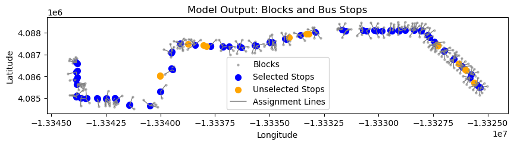

```
Gurobi Optimizer version 11.0.1 build v11.0.1rc0 (mac64[arm] - Darwin 22.1.0 22A400)

CPU model: Apple M1
Thread count: 8 physical cores, 8 logical processors, using up to 8 threads

Optimize a model with 15689 rows, 15444 columns and 31349 nonzeros
Model fingerprint: 0x4c21ee75
Variable types: 0 continuous, 15444 integer (15444 binary)
Coefficient statistics:
  Matrix range     [1e+00, 1e+00]
  Objective range  [2e+02, 5e+07]
  Bounds range     [1e+00, 1e+00]
  RHS range        [1e+00, 4e+01]
Presolve removed 15651 rows and 15412 columns
Presolve time: 0.02s
Presolved: 38 rows, 32 columns, 86 nonzeros
Variable types: 0 continuous, 32 integer (32 binary)
Found heuristic solution: objective 8038175.3412
Found heuristic solution: objective 7831714.7594

Root relaxation: objective 7.769014e+06, 20 iterations, 0.00 seconds (0.00 work units)

    Nodes    |    Current Node    |     Objective Bounds      |     Work
 Expl Unexpl |  Obj  Depth IntInf | Incumbent    BestBd   Gap | It/Node Time

*    0     0               0    7769013.7876 7769013.79  0.00%     -    0s

Explored 1 nodes (20 simplex iterations) in 0.05 seconds (0.02 work units)
Thread count was 8 (of 8 available processors)

Solution count 3: 7.76901e+06 7.83171e+06 8.03818e+06

Optimal solution found (tolerance 1.00e-04)
Best objective 7.769013787609e+06, best bound 7.769013787609e+06, gap 0.0000%
```

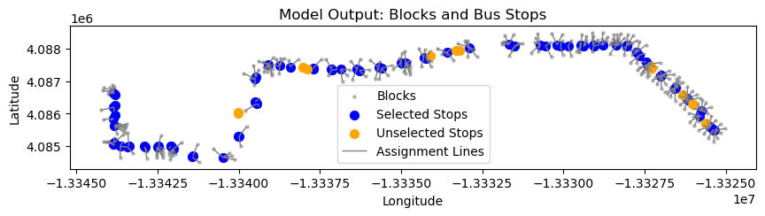

```
Gurobi Optimizer version 11.0.1 build v11.0.1rc0 (mac64[arm] - Darwin 22.1.0 22A400)

CPU model: Apple M1
Thread count: 8 physical cores, 8 logical processors, using up to 8 threads

Optimize a model with 15689 rows, 15444 columns and 31349 nonzeros
Model fingerprint: 0x0de0f36f
Variable types: 0 continuous, 15444 integer (15444 binary)
Coefficient statistics:
  Matrix range     [1e+00, 1e+00]
  Objective range  [2e+02, 5e+07]
  Bounds range     [1e+00, 1e+00]
  RHS range        [1e+00, 4e+01]
Presolve removed 15651 rows and 15412 columns
Presolve time: 0.02s
Presolved: 38 rows, 32 columns, 86 nonzeros
Variable types: 0 continuous, 32 integer (32 binary)
Found heuristic solution: objective 7809454.8314
Found heuristic solution: objective 7726875.2892

Root relaxation: interrupted, 18 iterations, 0.00 seconds (0.00 work units)

    Nodes    |    Current Node    |     Objective Bounds      |     Work
 Expl Unexpl |  Obj  Depth IntInf | Incumbent    BestBd   Gap | It/Node Time

     0     0          -    0      7726875.29 7726281.55  0.01%     -    0s

Explored 1 nodes (18 simplex iterations) in 0.03 seconds (0.02 work units)
Thread count was 8 (of 8 available processors)

Solution count 2: 7.72688e+06 7.80945e+06

Optimal solution found (tolerance 1.00e-04)
Best objective 7.726875289215e+06, best bound 7.726281547071e+06, gap 0.0077%
```

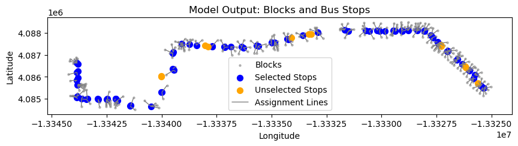

```
Gurobi Optimizer version 11.0.1 build v11.0.1rc0 (mac64[arm] - Darwin 22.1.0 22A400)

CPU model: Apple M1
Thread count: 8 physical cores, 8 logical processors, using up to 8 threads

Optimize a model with 15689 rows, 15444 columns and 31349 nonzeros
Model fingerprint: 0x52b2dfe9
Variable types: 0 continuous, 15444 integer (15444 binary)
Coefficient statistics:
  Matrix range     [1e+00, 1e+00]
  Objective range  [2e+02, 5e+07]
  Bounds range     [1e+00, 1e+00]
  RHS range        [1e+00, 5e+01]
Presolve removed 15651 rows and 15412 columns
Presolve time: 0.02s
Presolved: 38 rows, 32 columns, 86 nonzeros
Variable types: 0 continuous, 32 integer (32 binary)
Found heuristic solution: objective 7704615.3613

Root relaxation: objective 7.685595e+06, 17 iterations, 0.00 seconds (0.00 work units)

    Nodes    |    Current Node    |     Objective Bounds      |     Work
 Expl Unexpl |  Obj  Depth IntInf | Incumbent    BestBd   Gap | It/Node Time

*    0     0               0    7685595.0842 7685595.08  0.00%     -    0s

Explored 1 nodes (17 simplex iterations) in 0.03 seconds (0.02 work units)
Thread count was 8 (of 8 available processors)

Solution count 2: 7.6856e+06 7.70462e+06

Optimal solution found (tolerance 1.00e-04)
Best objective 7.685595084200e+06, best bound 7.685595084200e+06, gap 0.0000%
```

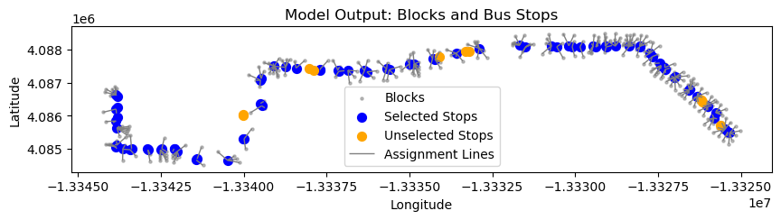

```
Gurobi Optimizer version 11.0.1 build v11.0.1rc0 (mac64[arm] - Darwin 22.1.0 22A400)

CPU model: Apple M1
Thread count: 8 physical cores, 8 logical processors, using up to 8 threads

Optimize a model with 15689 rows, 15444 columns and 31349 nonzeros
Model fingerprint: 0xbb38e834
Variable types: 0 continuous, 15444 integer (15444 binary)
Coefficient statistics:
  Matrix range     [1e+00, 1e+00]
  Objective range  [2e+02, 5e+07]
  Bounds range     [1e+00, 1e+00]
  RHS range        [1e+00, 5e+01]
Presolve removed 15651 rows and 15412 columns
Presolve time: 0.02s
Presolved: 38 rows, 32 columns, 86 nonzeros
Variable types: 0 continuous, 32 integer (32 binary)
Found heuristic solution: objective 7663335.1562

Root relaxation: interrupted, 12 iterations, 0.00 seconds (0.00 work units)

    Nodes    |    Current Node    |     Objective Bounds      |     Work
 Expl Unexpl |  Obj  Depth IntInf | Incumbent    BestBd   Gap | It/Node Time

     0     0          -    0      7663335.16 7662752.62  0.01%     -    0s

Explored 1 nodes (12 simplex iterations) in 0.02 seconds (0.02 work units)
Thread count was 8 (of 8 available processors)

Solution count 1: 7.66334e+06

Optimal solution found (tolerance 1.00e-04)
Best objective 7.663335156241e+06, best bound 7.662752618066e+06, gap 0.0076%
```

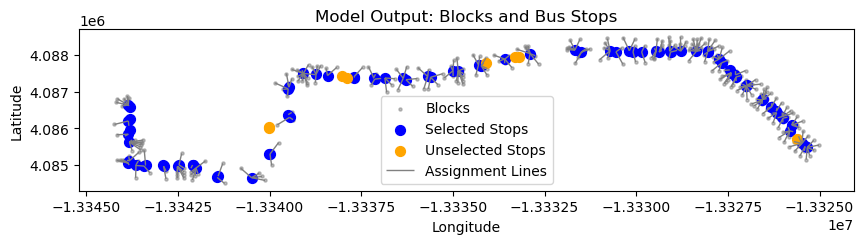

```
Gurobi Optimizer version 11.0.1 build v11.0.1rc0 (mac64[arm] - Darwin 22.1.0 22A400)

CPU model: Apple M1
Thread count: 8 physical cores, 8 logical processors, using up to 8 threads

Optimize a model with 15689 rows, 15444 columns and 31349 nonzeros
Model fingerprint: 0x6d9a87d4
Variable types: 0 continuous, 15444 integer (15444 binary)
Coefficient statistics:
  Matrix range     [1e+00, 1e+00]
  Objective range  [2e+02, 5e+07]
  Bounds range     [1e+00, 1e+00]
  RHS range        [1e+00, 5e+01]
Presolve removed 15651 rows and 15412 columns
Presolve time: 0.02s
Presolved: 38 rows, 32 columns, 86 nonzeros
Variable types: 0 continuous, 32 integer (32 binary)
Found heuristic solution: objective 7643574.2081

Root relaxation: interrupted, 13 iterations, 0.00 seconds (0.00 work units)

    Nodes    |    Current Node    |     Objective Bounds      |     Work
 Expl Unexpl |  Obj  Depth IntInf | Incumbent    BestBd   Gap | It/Node Time

     0     0          -    0      7643574.21 7642958.95  0.01%     -    0s

Explored 1 nodes (13 simplex iterations) in 0.03 seconds (0.02 work units)
Thread count was 8 (of 8 available processors)

Solution count 1: 7.64357e+06

Optimal solution found (tolerance 1.00e-04)
Best objective 7.643574208053e+06, best bound 7.642958952285e+06, gap 0.0080%
```

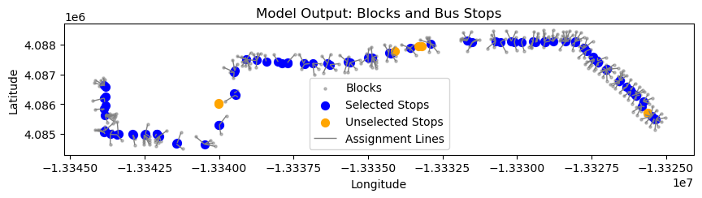

```
Gurobi Optimizer version 11.0.1 build v11.0.1rc0 (mac64[arm] - Darwin 22.1.0 22A400)

CPU model: Apple M1
Thread count: 8 physical cores, 8 logical processors, using up to 8 threads

Optimize a model with 15689 rows, 15444 columns and 31349 nonzeros
Model fingerprint: 0xd3dbe551
Variable types: 0 continuous, 15444 integer (15444 binary)
Coefficient statistics:
  Matrix range     [1e+00, 1e+00]
  Objective range  [2e+02, 5e+07]
  Bounds range     [1e+00, 1e+00]
  RHS range        [1e+00, 5e+01]
Found heuristic solution: objective 8967060.7690
Presolve removed 15651 rows and 15412 columns
Presolve time: 0.01s
Presolved: 38 rows, 32 columns, 86 nonzeros
Found heuristic solution: objective 7629548.3825
Variable types: 0 continuous, 32 integer (32 binary)

Root relaxation: cutoff, 11 iterations, 0.00 seconds (0.00 work units)

    Nodes    |    Current Node    |     Objective Bounds      |     Work
 Expl Unexpl |  Obj  Depth IntInf | Incumbent    BestBd   Gap | It/Node Time

     0     0     cutoff    0      7629548.38 7629548.38  0.00%     -    0s

Explored 1 nodes (11 simplex iterations) in 0.03 seconds (0.01 work units)
Thread count was 8 (of 8 available processors)

Solution count 2: 7.62955e+06 8.96706e+06

Optimal solution found (tolerance 1.00e-04)
Best objective 7.629548382539e+06, best bound 7.629548382539e+06, gap 0.0000%
```

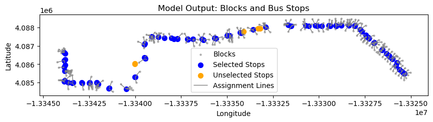

```
Gurobi Optimizer version 11.0.1 build v11.0.1rc0 (mac64[arm] - Darwin 22.1.0 22A400)

CPU model: Apple M1
Thread count: 8 physical cores, 8 logical processors, using up to 8 threads

Optimize a model with 15689 rows, 15444 columns and 31349 nonzeros
Model fingerprint: 0xf1bfd9fe
Variable types: 0 continuous, 15444 integer (15444 binary)
Coefficient statistics:
  Matrix range     [1e+00, 1e+00]
  Objective range  [2e+02, 5e+07]
  Bounds range     [1e+00, 1e+00]
  RHS range        [1e+00, 5e+01]
Found heuristic solution: objective 8967060.7690
Presolve removed 15651 rows and 15413 columns
Presolve time: 0.02s
Presolved: 38 rows, 31 columns, 85 nonzeros
Found heuristic solution: objective 7620446.1000
Variable types: 0 continuous, 31 integer (31 binary)

Root relaxation: cutoff, 9 iterations, 0.00 seconds (0.00 work units)

    Nodes    |    Current Node    |     Objective Bounds      |     Work
 Expl Unexpl |  Obj  Depth IntInf | Incumbent    BestBd   Gap | It/Node Time

     0     0     cutoff    0      7620446.10 7620446.10  0.00%     -    0s

Explored 1 nodes (9 simplex iterations) in 0.03 seconds (0.01 work units)
Thread count was 8 (of 8 available processors)

Solution count 2: 7.62045e+06 8.96706e+06

Optimal solution found (tolerance 1.00e-04)
Best objective 7.620446099991e+06, best bound 7.620446099991e+06, gap 0.0000%
```

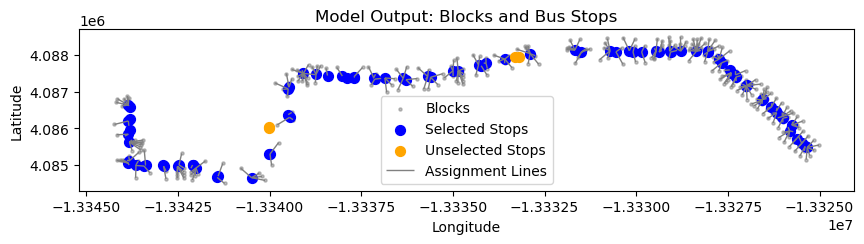

```
Gurobi Optimizer version 11.0.1 build v11.0.1rc0 (mac64[arm] - Darwin 22.1.0 22A400)

CPU model: Apple M1
Thread count: 8 physical cores, 8 logical processors, using up to 8 threads

Optimize a model with 15689 rows, 15444 columns and 31349 nonzeros
Model fingerprint: 0xaf4181a2
Variable types: 0 continuous, 15444 integer (15444 binary)
Coefficient statistics:
  Matrix range     [1e+00, 1e+00]
  Objective range  [2e+02, 5e+07]
  Bounds range     [1e+00, 1e+00]
  RHS range        [1e+00, 5e+01]
Found heuristic solution: objective 8966317.1946
Presolve removed 15689 rows and 15444 columns
Presolve time: 0.01s
Presolve: All rows and columns removed

Explored 0 nodes (0 simplex iterations) in 0.02 seconds (0.01 work units)
Thread count was 1 (of 8 available processors)

Solution count 2: 7.61755e+06 8.96632e+06

Optimal solution found (tolerance 1.00e-04)
Best objective 7.617549170489e+06, best bound 7.617549170489e+06, gap 0.0000%
```

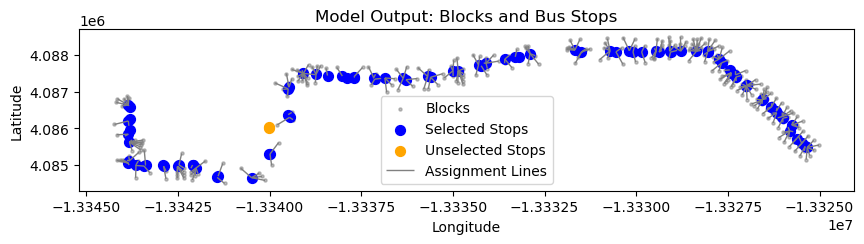

```
Gurobi Optimizer version 11.0.1 build v11.0.1rc0 (mac64[arm] - Darwin 22.1.0 22A400)

CPU model: Apple M1
Thread count: 8 physical cores, 8 logical processors, using up to 8 threads

Optimize a model with 15689 rows, 15444 columns and 31349 nonzeros
Model fingerprint: 0xf5e11271
Variable types: 0 continuous, 15444 integer (15444 binary)
Coefficient statistics:
  Matrix range     [1e+00, 1e+00]
  Objective range  [2e+02, 5e+07]
  Bounds range     [1e+00, 1e+00]
  RHS range        [1e+00, 5e+01]
Found heuristic solution: objective 8966317.1946
Presolve removed 15689 rows and 15444 columns
Presolve time: 0.00s
Presolve: All rows and columns removed

Explored 0 nodes (0 simplex iterations) in 0.01 seconds (0.01 work units)
Thread count was 1 (of 8 available processors)

Solution count 2: 7.61755e+06 8.96632e+06

Optimal solution found (tolerance 1.00e-04)
Best objective 7.617549170489e+06, best bound 7.617549170489e+06, gap 0.0000%
```

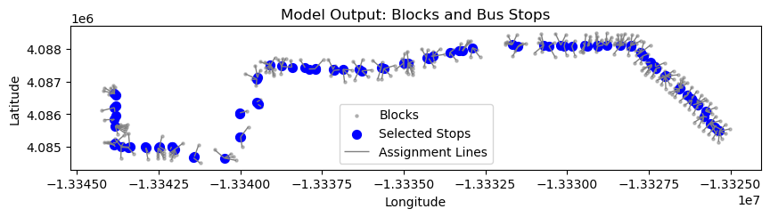

```python
# Put your P_range here
P_range = range(42,53)

# Start three empty lists here.
selecteds = []
z_lines_list = []
objs = []

# Run your function with P_range values
for P in P_range:
    s,z,o = solve_m(P)

    selecteds.append(s)
    z_lines_list.append(z)
    objs.append(o)
```

#### Task: Recalculate the objective value, which represents the average travel distance.

- Currently, the objective value indicates the total weighted distance, representing the total distance people living in the blocks will take to get to the assigned bus stops.
- However, we want to obtain the average distance.
- To achieve this, divide the total weighted distance by the total population of blocks.

**Hint:** Convert the `objs` list into a numpy array.  
A numpy array divided by a constant number will return a new numpy array, where the original numpy array elements are divided by the constant number.

```python
objs = np.array(objs)
objs = objs/blocks["Population"].sum()

objs
```

```
array([250.5666502 , 243.4936221 , 240.25153192, 238.94842716,
       237.67186456, 236.98349124, 236.37239719, 235.93865796,
       235.65717599, 235.56759039, 235.56759039])
```

#### Question 9: Draw a scatter plot showing the average travel distance according to the number of bus stops along Bus 11. ( 1 pt )

- The x-axis must represent the P_range and the y-axis must represent the objective values. (0.5 pts)
- Include title and labels for the x-axis and y-axis with **the unit specified**. (0.5 pts)

```python
import matplotlib.pyplot as plt
from importlib import reload
plt=reload(plt)
```

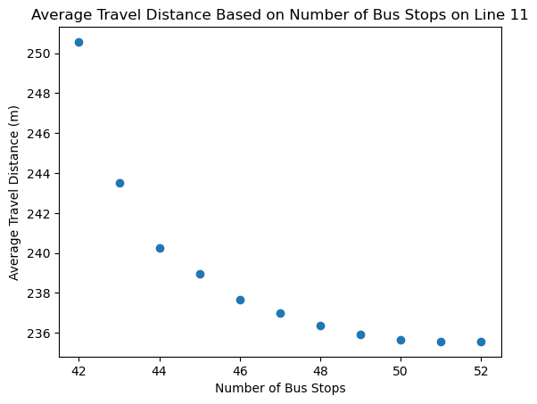

```python
plt.figure()
plt.scatter(P_range, objs)
plt.xlabel("Number of Bus Stops")
plt.ylabel("Average Travel Distance (m)")
plt.title("Average Travel Distance Based on Number of Bus Stops on Line 11")
```

```python
from shapely.geometry import LineString
from shapely.ops import nearest_points
from shapely.geometry import LineString

Z_lines = []

for i in range(I):
    for j in range(J):
        if Z_ij[i, j].X > 0.5:
            Z_lines.append(LineString(nearest_points(blocks.centroid[i], fin_stops.geometry[j])))

# Check if all elements in Z_lines are LineString objects
if not all(isinstance(line, LineString) for line in Z_lines):
    raise ValueError("Not all elements in Z_lines are LineString objects.")
```

```python
import geopandas as gpd

# Ensure Z_lines is a valid list of LineString objects
geo_series = gpd.GeoSeries(Z_lines, crs=blocks.crs)

# Check if GeoSeries is created successfully
print(geo_series)

# Convert GeoSeries to GeoDataFrame
Z_lines_gdf = gpd.GeoDataFrame(geometry=geo_series)

# Transform the CRS to EPSG:4326
Z_lines_4326 = Z_lines_gdf.to_crs(epsg=4326)

# Check the transformed GeoDataFrame
print(Z_lines_4326)
```

```
0      LINESTRING (-13334719.252 4087195.059, -133348...
1      LINESTRING (-13333029.139 4088231.979, -133328...
2      LINESTRING (-13336257.925 4087684.439, -133363...
3      LINESTRING (-13343881.524 4086880.750, -133438...
4      LINESTRING (-13341748.272 4085110.481, -133420...
                             ...
291    LINESTRING (-13344151.250 4086805.299, -133438...
292    LINESTRING (-13342029.785 4084706.597, -133420...
293    LINESTRING (-13334718.691 4087618.227, -133348...
294    LINESTRING (-13339115.263 4087583.051, -133390...
295    LINESTRING (-13325414.101 4085383.743, -133253...
Length: 296, dtype: geometry
                                              geometry
0    LINESTRING (-119.78782 34.43376, -119.78905 34...
1    LINESTRING (-119.77264 34.44144, -119.77142 34...
2    LINESTRING (-119.80164 34.43738, -119.80251 34...
3    LINESTRING (-119.87013 34.43143, -119.86988 34...
4    LINESTRING (-119.85096 34.41831, -119.85328 34...
..                                                 ...
291  LINESTRING (-119.87255 34.43087, -119.86988 34...
292  LINESTRING (-119.85349 34.41532, -119.85328 34...
293  LINESTRING (-119.78782 34.43689, -119.78905 34...
294  LINESTRING (-119.82731 34.43663, -119.82696 34...
295  LINESTRING (-119.70423 34.42034, -119.70405 34...

[296 rows x 1 columns]
```

#### Question 10: Pick the P value that you think is most desirable and create a folium plot that shows the model output. ( 1 pt )

```
Gurobi Optimizer version 11.0.1 build v11.0.1rc0 (mac64[arm] - Darwin 22.1.0 22A400)

CPU model: Apple M1
Thread count: 8 physical cores, 8 logical processors, using up to 8 threads

Optimize a model with 15689 rows, 15444 columns and 31349 nonzeros
Model fingerprint: 0x52b2dfe9
Variable types: 0 continuous, 15444 integer (15444 binary)
Coefficient statistics:
  Matrix range     [1e+00, 1e+00]
  Objective range  [2e+02, 5e+07]
  Bounds range     [1e+00, 1e+00]
  RHS range        [1e+00, 5e+01]
Presolve removed 15651 rows and 15412 columns
Presolve time: 0.01s
Presolved: 38 rows, 32 columns, 86 nonzeros
Variable types: 0 continuous, 32 integer (32 binary)
Found heuristic solution: objective 7704615.3613

Root relaxation: objective 7.685595e+06, 17 iterations, 0.00 seconds (0.00 work units)

    Nodes    |    Current Node    |     Objective Bounds      |     Work
 Expl Unexpl |  Obj  Depth IntInf | Incumbent    BestBd   Gap | It/Node Time

*    0     0               0    7685595.0842 7685595.08  0.00%     -    0s

Explored 1 nodes (17 simplex iterations) in 0.02 seconds (0.02 work units)
Thread count was 8 (of 8 available processors)

Solution count 2: 7.6856e+06 7.70462e+06

Optimal solution found (tolerance 1.00e-04)
Best objective 7.685595084200e+06, best bound 7.685595084200e+06, gap 0.0000%
```

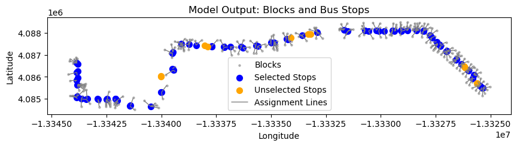

```python
selected_stops, unselected_stops, Z_lines = solve_m(46)
```

```python
#gpd.GeoSeries(Z_lines, crs=blocks.crs)
```

```python
import geopandas as gpd

# Assuming selected_stops_4326 and unselected_stops_4326 are GeoSeries
selected_stops_gdf = gpd.GeoDataFrame(geometry=selected_stops_4326)
unselected_stops_gdf = gpd.GeoDataFrame(geometry=unselected_stops_4326)
blocks_4326 = blocks.to_crs(epsg=4326)

import folium

# Create a folium map
m = folium.Map(location=[blocks_4326.geometry.centroid.y.mean(), blocks_4326.geometry.centroid.x.mean()], zoom_start=12)

for idx, row in blocks_4326.iterrows():
    #Create circle markers for centroids of blocks with popup information
    folium.CircleMarker(
        location=[row.geometry.centroid.y, row.geometry.centroid.x],
        radius=3,
        popup= "Blocks",
        color='grey',
        fill_opacity=0.6,
        fill_color='gray'

    ).add_to(m)

# Plot selected stops
for idx, stop in selected_stops_gdf.iterrows():
    folium.CircleMarker(
        location=[stop.geometry.centroid.y, stop.geometry.centroid.x],
        radius=7,
        popup=f"Selected Stop {idx}",
        color='blue',
        fill_opacity=0.6,
        fill_color='blue'
    ).add_to(m)

# Plot unselected stops
for idx, stop in unselected_stops_gdf.iterrows():
    folium.CircleMarker(
        location=[stop.geometry.centroid.y, stop.geometry.centroid.x],
        radius=7,
        popup=f"Unselected Stop {idx}",
        color='orange',
        fill_opacity=0.6,
        fill_color='orange'
    ).add_to(m)

# Add assignment lines
for line in Z_lines_gdf_4326.geometry:
    folium.GeoJson(line, style_function=lambda x: {'color': 'gray', 'weight': 1}).add_to(m)


# Save the map to an HTML file
m.save("map.html")
m
```

Make this Notebook Trusted to load map: File -> Trust Notebook

[interactive chart not shown]

#### Question 11: Explain why you picked the P value as the most desirable and discuss your findings from Lab 5. ( 2 pts )

**Things you can discuss**

- [MUST]: Why you picked the P value as the most desirable.
- [MUST]: How to interpret the model results according to P.
- Estimate how much travel time will be reduced with your P number.
- Insights from the model results.
- Limitations of the model.

##### Put your ANSWER in this markdown cell

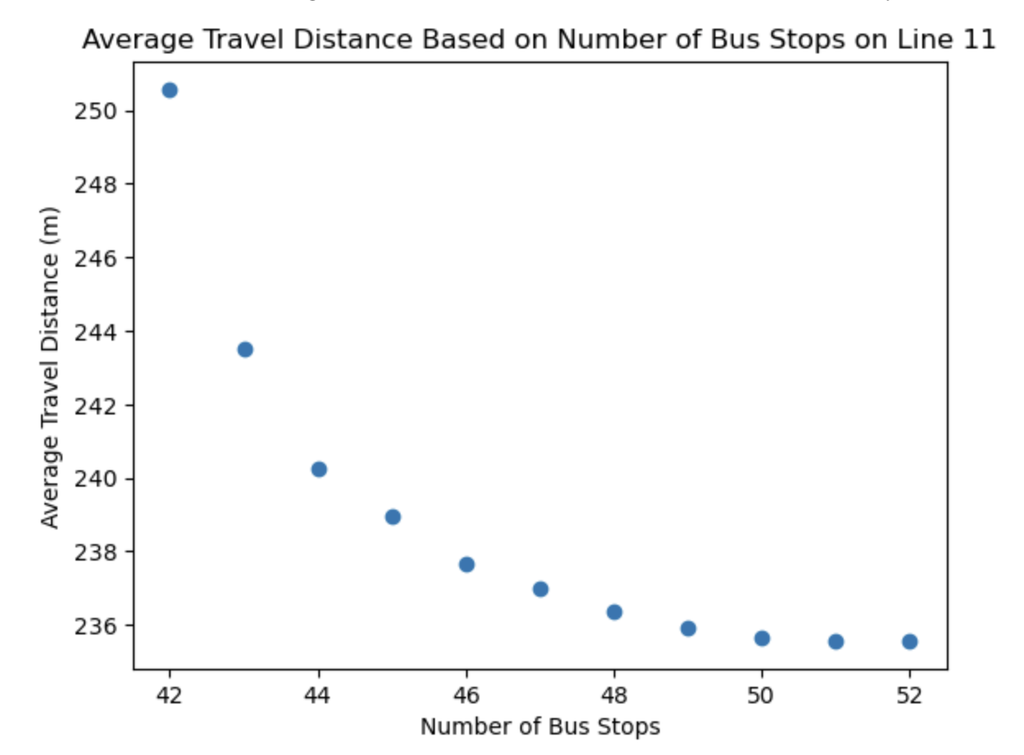

... Limitations of the model include technicalities that come with implementation. For example, it is unlikely that everybody will agree with the closing of certain bus stops, as there may be people who would be upset if a bus stop that's next to their house is removed, forcing them to walk a lot more every day. In addition, the model doesn't take ADA requirements into account, therefore, we don't know if the bus stop selection still allows access to people with transportation-related disabilities. Lastly, while the model does include block populations, it does not take into account the surroudning infrastructure around specific bus stops. For example, there is a hostpial near one of the bus stops that the model doesn't account for access to. In addition, the model doesn't take data about inflow and outflow of bus riders at each bus stop, which is a limitation.